# 6 Building ARIMA model

```python
#Require Packages
import numpy as np
import pandas as pd
import matplotlib.pyplot as plt
```

## 6.1 Import final data frame

```python
df = pd.read_csv(r"/Users/user/Downloads/df_FINAL.csv")
df.head()
```

|  | Unnamed: 0 | arrival_date | Demand |
| --- | --- | --- | --- |
| 0 | 1 | 2015-07-01 | 116 |
| 1 | 2 | 2015-07-02 | 1 |
| 2 | 3 | 2015-07-03 | 18 |
| 3 | 4 | 2015-07-04 | 16 |
| 4 | 5 | 2015-07-06 | 2 |

### Define date column as an index.

```python
df.rename(columns = {'arrival_date':'Date'}, inplace = True)
df['Date']= pd.to_datetime(df['Date'])
df.index = df['Date']
df.sort_index(inplace=True)
df.head()
```

| Date | Unnamed: 0 | Date | Demand |
| --- | --- | --- | --- |
| 2015-07-01 | 1 | 2015-07-01 | 116 |
| 2015-07-02 | 2 | 2015-07-02 | 1 |
| 2015-07-03 | 3 | 2015-07-03 | 18 |
| 2015-07-04 | 4 | 2015-07-04 | 16 |
| 2015-07-06 | 5 | 2015-07-06 | 2 |

```python
df = df[["Demand"]]
df.head()
```

| Date | Demand |
| --- | --- |
| 2015-07-01 | 116 |
| 2015-07-02 | 1 |
| 2015-07-03 | 18 |
| 2015-07-04 | 16 |
| 2015-07-06 | 2 |

## 6.2 Autocorrelation & Partial Autocorrelation Function

In order to indicate which past series values are more useful to predict future values, we are going to apply both functions **Autocorrelation** & **Partial Autocorrelation** to analyse the correlation between the values of our dependent variable (demand).

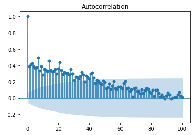

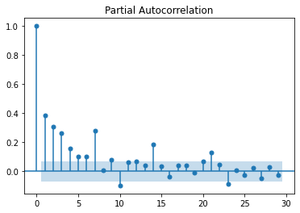

```python
from statsmodels.graphics.tsaplots import plot_acf, plot_pacf

plot_acf(df['Demand'], lags=100)
plt.show()

plot_pacf(df['Demand'])
plt.show()
```

The results show that we have enough correlation between the values of the variable demand and this justifies our choice of **ARIMA model**.

## 6.3 Monthly box plot

In this section we want to use the monthly box plot to check the lowest and the highest average of the demand per month

[figure not shown]

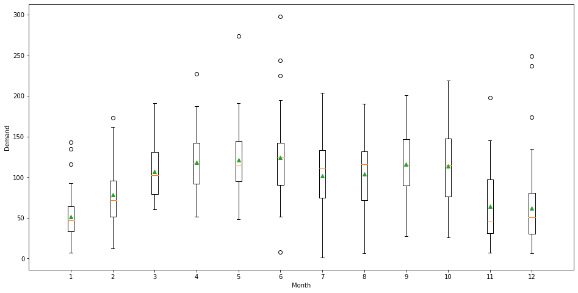

```python
plt.title("Monthly Boxplots")
plt.figure(figsize=(16,8))

for month in range(1, 13):
    plt.boxplot(df[df.index.month==month]["Demand"].dropna(), positions=[month], showmeans=True)
    plt.xticks(ticks=range(1, 13), labels=range(1, 13))
    plt.ylabel("Demand")
    plt.xlabel("Month")
    plt.xlim(0, 13)
```